# UI Take-Up and the Composition of Unemployment

Aryan Safi

2026-03-31

## UI Take-Up Is Low Relative to History

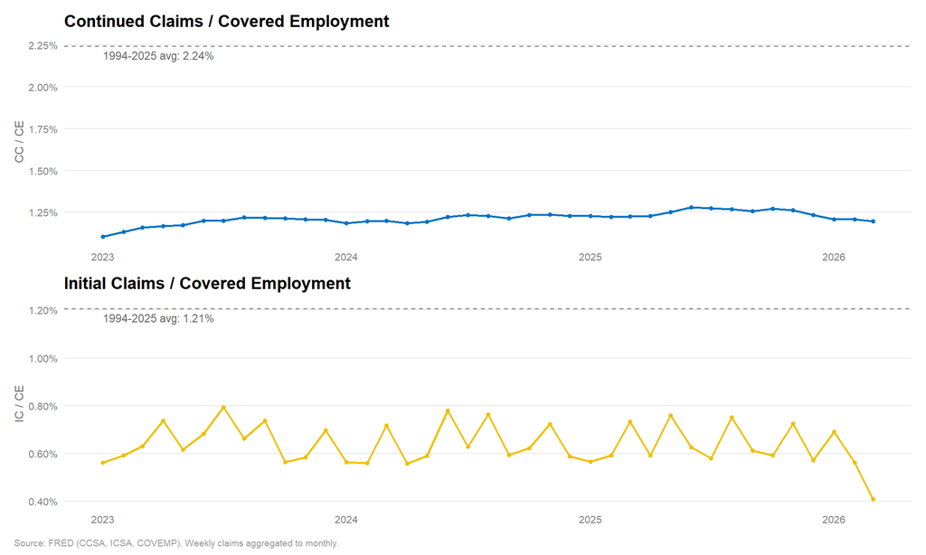

## People Are Saying…

**Two main stories:**

1. **Eligibility / composition story.** A larger share of the unemployed may be made up of workers with weak UI eligibility, especially **new entrants** with no prior work history, and possibly some **migrant groups**.
2. **Claim-propensity story.** Even among plausibly eligible workers, some groups may be less likely to claim UI because the costs of claiming are high relative to the expected benefit. One candidate mechanism is that some displaced **white-collar workers** receive severance packages or expect rapid re-employment and therefore do not bother filing.

**Our question:** Does variation in the state-time composition of unemployment help explain variation in UI claims intensity and IUR?

## New Entrants: A Proxy for Weak Eligibility

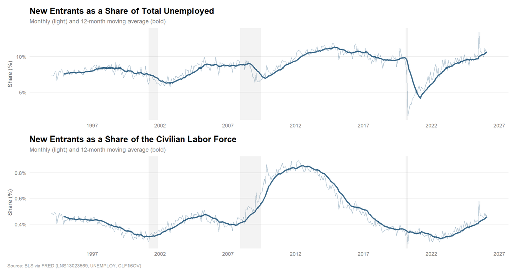

## Who Comprises the Unemployed? (1)

The CPS classifies every unemployed person into one of six mutually exclusive categories.

| Category | BLS Definition | Two-Group |
| --- | --- | --- |
| Temporary Layoff | Given a return date or expects recall within 6 months | Job Separations |
| Permanent Job Losers | Permanently separated – position eliminated, fired, or employer closed | Job Separations |
| Completed Temp Job | Temporary job or assignment has ended | Job Separations |
| Job Leavers | Voluntarily quit and now actively searching | Job Separations |
| Reentrants | Previously held a job, left the labor force, now returned to searching | Labor Force Entry |
| New Entrants | Never held a job; actively looking for first one | Labor Force Entry |

## Who Comprises the Cause Categories? (1a)

Dominant demographic group on each margin, pooled CPS 1994–present: **Job Separation** causes.

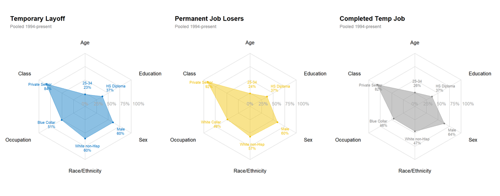

## Who Comprises the Cause Categories? (1b)

Dominant demographic group on each margin, pooled CPS 1994–present: **Job Separation** (cont.) and **Labor Force Entry** causes.

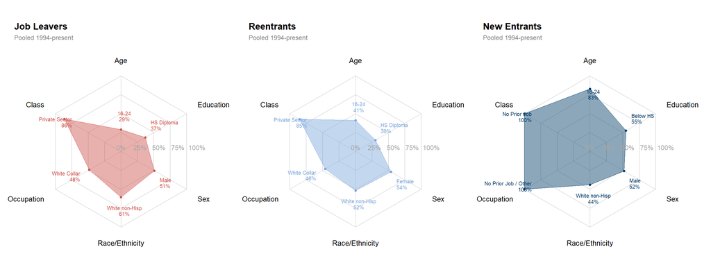

## Who Comprises the Cause Categories? (2a)

Change in dominant-group share, 2025 vs. pooled (pp): **Job Separation** causes.

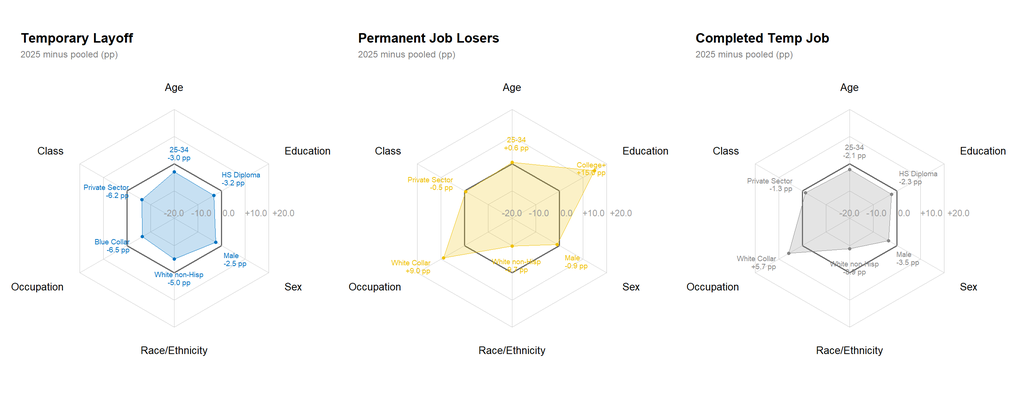

## Who Comprises the Cause Categories? (2b)

Change in dominant-group share, 2025 vs. pooled (pp): **Job Separation** (cont.) and **Labor Force Entry** causes.

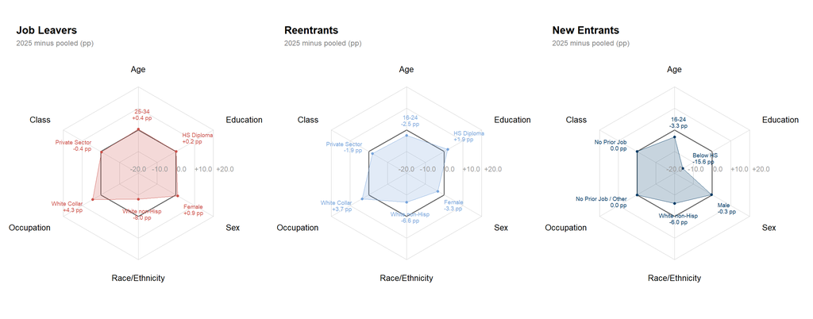

## Who Comprises the Unemployed? (2)

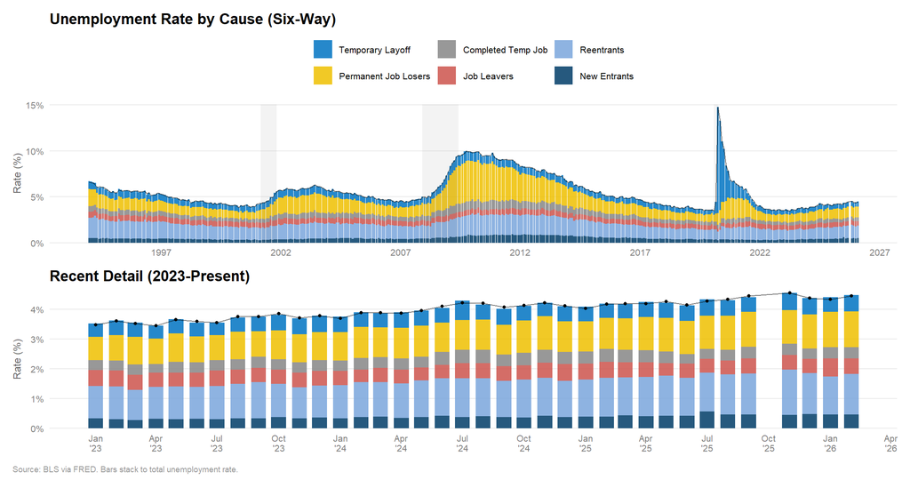

## Who Comprises the Unemployed? (3)

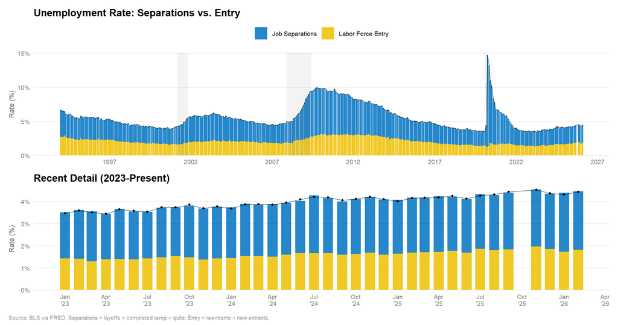

## Who Is Driving Changes in Unemployment? (1)

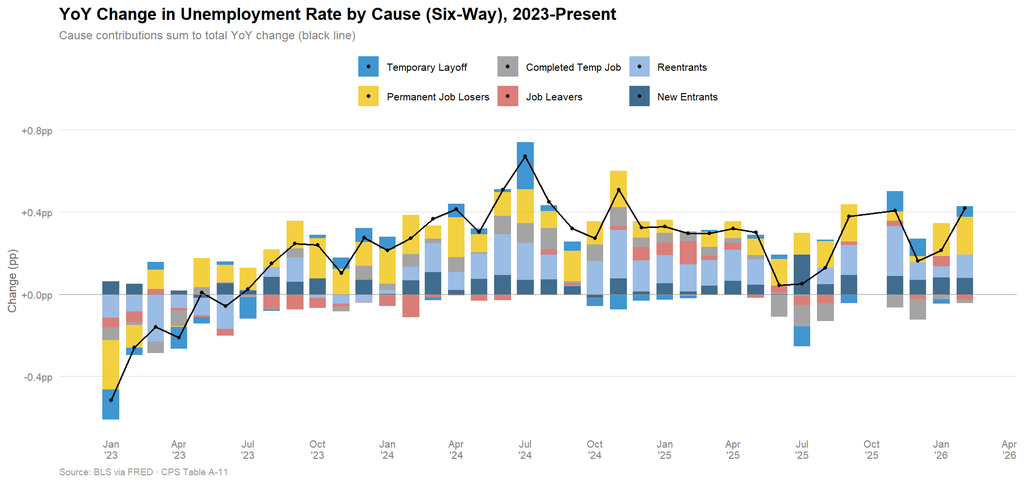

## Who Is Driving Changes in Unemployment? (2)

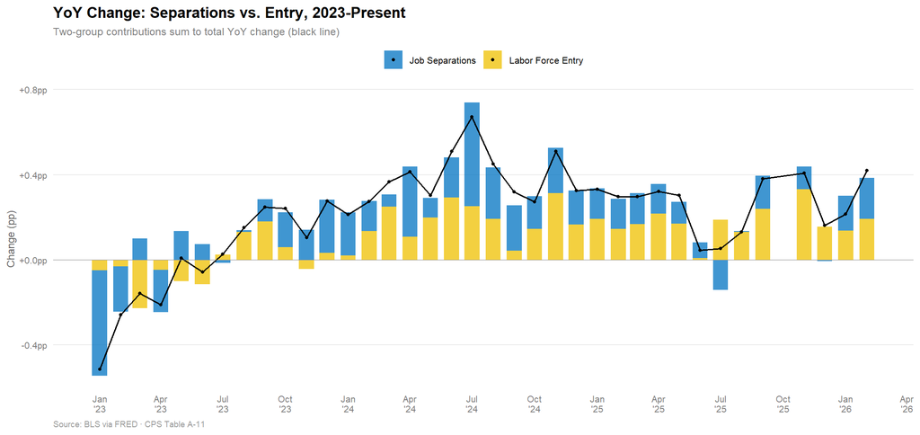